# 0525_모델평가_주성분분석

## 주성분 분석

- 정의: 변수 간의 관계(공분산, 상관)를 기반으로 정보 손실을 최소화하면서 주요 성분을 확인하고 차원을 축소하는 기법
- 주요 성분 확인
- 차원 축소: 변수를 축약하여 정보를 쉽게 표현
- 유의 사항: 변수의 scale이 유사해야 한다.
  - scale이 유사하면 공분산 행렬
  - scale 차이가 크면 상관계수 이용

```python
import pandas as pd
import matplotlib
import matplotlib.pyplot as plt
import seaborn as sns

# Scale 변환-> 설명변수 변환 : 회귀분석.설명변수 회귀계수 표준화
from sklearn.preprocessing import StandardScaler

import statsmodels.api as sm
from sklearn.decomposition import PCA
```

```python
df_raw = pd.read_csv("../빅데이터 기초/Data/직무능력평가.csv")
df_raw.head()
```

|  | EVAL | DISSATIS | PRIVILEGE | CHANCE | ADVANCE | CRITISM | PROMOTION |
| --- | --- | --- | --- | --- | --- | --- | --- |
| 0 | 43 | 51 | 30 | 39 | 61 | 92 | 45 |
| 1 | 63 | 64 | 51 | 54 | 63 | 73 | 47 |
| 2 | 71 | 70 | 68 | 69 | 76 | 86 | 48 |
| 3 | 61 | 63 | 45 | 47 | 54 | 84 | 35 |
| 4 | 81 | 78 | 56 | 66 | 71 | 83 | 47 |

```python
# 데이터 분리 (Y, Xs) -> 설명변수를 이용한 주성분 분석
df_raw_x = df_raw.drop("EVAL", axis = 1)
df_raw_y = df_raw["EVAL"]
df_raw_y.head()
```

```
0    43
1    63
2    71
3    61
4    81
Name: EVAL, dtype: int64
```

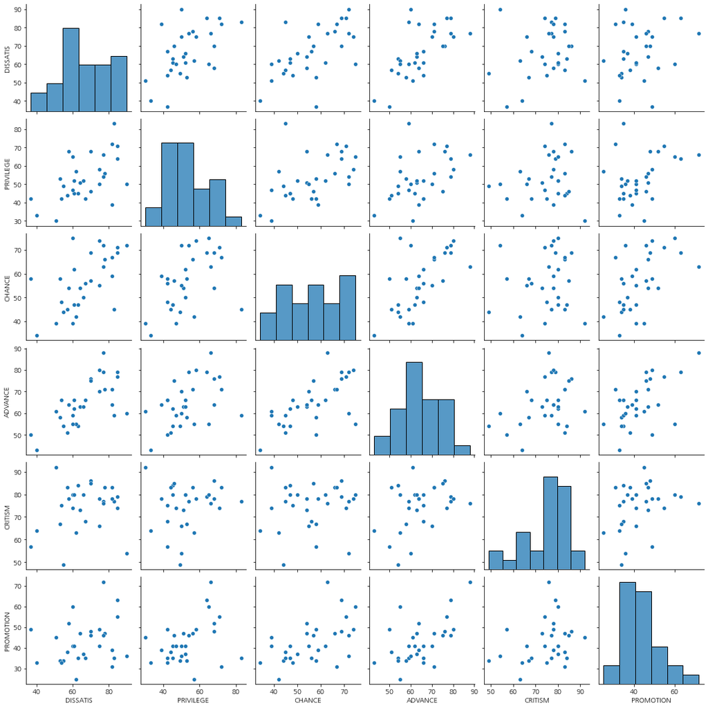

```python
# 산점도 행렬
sns.pairplot(df_raw_x)
```

```python
# Pearson 상관계수 : pearson, kendall, spearman
df_raw_x.corr().round(3)
```

|  | DISSATIS | PRIVILEGE | CHANCE | ADVANCE | CRITISM | PROMOTION |
| --- | --- | --- | --- | --- | --- | --- |
| DISSATIS | 1.000 | 0.558 | 0.597 | 0.669 | 0.188 | 0.225 |
| PRIVILEGE | 0.558 | 1.000 | 0.493 | 0.445 | 0.147 | 0.343 |
| CHANCE | 0.597 | 0.493 | 1.000 | 0.640 | 0.116 | 0.532 |
| ADVANCE | 0.669 | 0.445 | 0.640 | 1.000 | 0.377 | 0.574 |
| CRITISM | 0.188 | 0.147 | 0.116 | 0.377 | 1.000 | 0.283 |
| PROMOTION | 0.225 | 0.343 | 0.532 | 0.574 | 0.283 | 1.000 |

-> DISSATIS는 CHANCE, ADVANCE와 상관관계가 높다.  
-> CHANCE는 ADVANCE와 상관관계가 높다.

```python
# 요약 통계량 -> Scale 변환 필요 확인
df_raw_x.describe().round(3)
```

|  | DISSATIS | PRIVILEGE | CHANCE | ADVANCE | CRITISM | PROMOTION |
| --- | --- | --- | --- | --- | --- | --- |
| count | 30.000 | 30.000 | 30.000 | 30.000 | 30.000 | 30.000 |
| mean | 66.600 | 53.133 | 56.367 | 64.633 | 74.767 | 42.933 |
| std | 13.315 | 12.235 | 11.737 | 10.397 | 9.895 | 10.289 |
| min | 37.000 | 30.000 | 34.000 | 43.000 | 49.000 | 25.000 |
| 25% | 58.500 | 45.000 | 47.000 | 58.250 | 69.250 | 35.000 |
| 50% | 65.000 | 51.500 | 56.500 | 63.500 | 77.500 | 41.000 |
| 75% | 77.000 | 62.500 | 66.750 | 71.000 | 80.000 | 47.750 |
| max | 90.000 | 83.000 | 75.000 | 88.000 | 92.000 | 72.000 |

```python
# 변수 이름 저장
x_cols = df_raw_x.columns
# Scale 변환: ndarray 형식
scaler = StandardScaler()
nd_scaled = scaler.fit_transform(df_raw_x)
# 변환된 데이터 및 형태 확인
print("Scaled Data : \n {}".format(nd_scaled[:5].round(3)))
print("Shape:\n {}".format(nd_scaled.shape))
```

```
Scaled Data :
 [[-1.192 -1.923 -1.505 -0.355  1.771  0.204]
 [-0.199 -0.177 -0.205 -0.16  -0.182  0.402]
 [ 0.26   1.236  1.095  1.112  1.155  0.501]
 [-0.275 -0.676 -0.812 -1.04   0.949 -0.784]
 [ 0.871  0.238  0.835  0.623  0.846  0.402]]
Shape:
 (30, 6)
```

```python
# DataFrame으로 저장
df_scaled = pd.DataFrame(nd_scaled, columns=x_cols)
df_scaled.head().round(3)
```

|  | DISSATIS | PRIVILEGE | CHANCE | ADVANCE | CRITISM | PROMOTION |
| --- | --- | --- | --- | --- | --- | --- |
| 0 | -1.192 | -1.923 | -1.505 | -0.355 | 1.771 | 0.204 |
| 1 | -0.199 | -0.177 | -0.205 | -0.160 | -0.182 | 0.402 |
| 2 | 0.260 | 1.236 | 1.095 | 1.112 | 1.155 | 0.501 |
| 3 | -0.275 | -0.676 | -0.812 | -1.040 | 0.949 | -0.784 |
| 4 | 0.871 | 0.238 | 0.835 | 0.623 | 0.846 | 0.402 |

```python
# Scale 변환 데이터 요약 통계량
df_scaled.describe().round(3)
```

|  | DISSATIS | PRIVILEGE | CHANCE | ADVANCE | CRITISM | PROMOTION |
| --- | --- | --- | --- | --- | --- | --- |
| count | 30.000 | 30.000 | 30.000 | 30.000 | 30.000 | 30.000 |
| mean | 0.000 | -0.000 | -0.000 | -0.000 | 0.000 | 0.000 |
| std | 1.017 | 1.017 | 1.017 | 1.017 | 1.017 | 1.017 |
| min | -2.261 | -1.923 | -1.938 | -2.116 | -2.649 | -1.773 |
| 25% | -0.619 | -0.676 | -0.812 | -0.624 | -0.567 | -0.784 |
| 50% | -0.122 | -0.136 | 0.012 | -0.111 | 0.281 | -0.191 |
| 75% | 0.794 | 0.779 | 0.900 | 0.623 | 0.538 | 0.476 |
| max | 1.787 | 2.483 | 1.615 | 2.286 | 1.771 | 2.873 |

-> 평균이 0, 표준편차가 약 1인 정규분포로 변환된 것을 확인할 수 있다.

```python
# 주성분 분석: 주성분1(Prin1)~주성분6(Prin6) 생성 및 저장
pca = PCA(n_components=6)
nd_pca = pca.fit_transform(df_scaled)

# 생성된 주성분 점수 확인
print("PCA Data : \n {}".format(nd_pca[:5]))

# 생성된 주성분 점수 Row, Col 개수 확인
print("Shape :\n {}".format(nd_pca.shape))
```

```
PCA Data :
 [[ 1.67606983 -2.73856419 -0.12843595 -0.50321261  0.24330658  0.22576117]
 [ 0.21834397 -0.12615302  0.43115839  0.08726221  0.19566103  0.1941439 ]
 [-2.10515127 -0.51500683 -0.27683087  0.49131136 -0.44691698 -0.63174369]
 [ 1.35994032 -0.86064574 -0.91799066  0.03173793 -0.40137177  0.44095403]
 [-1.5120347  -0.35277019 -0.32684445 -0.32877858 -0.32709718  0.21246099]]
Shape :
 (30, 6)
```

```python
# 주성분 점수 저장(Prin1~Prin6, DataFrame 형식) 및 확인
df_pca = pd.DataFrame(nd_pca,columns = ['Prin1','Prin2','Prin3','Prin4','Prin5','Prin6'])

# 주성분 분석용 데이터와 주성분 점수 결합
df_scaled_pca = df_scaled.join(df_pca)
df_scaled_pca.head()
```

|  | DISSATIS | PRIVILEGE | CHANCE | ADVANCE | CRITISM | PROMOTION | Prin1 | Prin2 | Prin3 | Prin4 | Prin5 | Prin6 |
| --- | --- | --- | --- | --- | --- | --- | --- | --- | --- | --- | --- | --- |
| 0 | -1.191662 | -1.923006 | -1.504945 | -0.355426 | 1.771410 | 0.204301 | 1.676070 | -2.738564 | -0.128436 | -0.503213 | 0.243307 | 0.225761 |
| 1 | -0.198610 | -0.177338 | -0.205088 | -0.159779 | -0.181595 | 0.402012 | 0.218344 | -0.126153 | 0.431158 | 0.087262 | 0.195661 | 0.194144 |
| 2 | 0.259721 | 1.235822 | 1.094768 | 1.111930 | 1.154672 | 0.500868 | -2.105151 | -0.515007 | -0.276831 | 0.491311 | -0.446917 | -0.631744 |
| 3 | -0.274999 | -0.676100 | -0.811688 | -1.040192 | 0.949092 | -0.784254 | 1.359940 | -0.860646 | -0.917991 | 0.031738 | -0.401372 | 0.440954 |
| 4 | 0.870830 | 0.238298 | 0.834797 | 0.622811 | 0.846302 | 0.402012 | -1.512035 | -0.352770 | -0.326844 | -0.328779 | -0.327097 | 0.212461 |

```python
# 주성분 분석 통계량 저장: 주성분 번호, Eigenvalue, Eigenvalue ratio
df_pca_stat = pd.DataFrame()
df_pca_stat["PrinNo"] = [l for l in range(1, 7)]
df_pca_stat["EigenValues"] = pca.explained_variance_
df_pca_stat["EigenValueRatio"] = pca.explained_variance_ratio_
df_pca_stat["CumEigenValueRatio"] = np.cumsum(pca.explained_variance_ratio_)
df_pca_stat.round(3)
```

|  | PrinNo | EigenValues | EigenValueRatio | CumEigenValueRatio |
| --- | --- | --- | --- | --- |
| 0 | 1 | 3.279 | 0.528 | 0.528 |
| 1 | 2 | 1.041 | 0.168 | 0.696 |
| 2 | 3 | 0.789 | 0.127 | 0.823 |
| 3 | 4 | 0.572 | 0.092 | 0.915 |
| 4 | 5 | 0.328 | 0.053 | 0.968 |
| 5 | 6 | 0.198 | 0.032 | 1.000 |

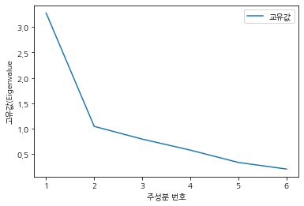

```python
# Scree Plot
plt.plot(df_pca_stat["PrinNo"], df_pca_stat["EigenValues"], label="교유값")

# 그래프 label, legend 설정
plt.ylabel("고유값(Eigenvalue)")
plt.xlabel("주성분 번호")
plt.legend(loc="best")
```

고유값 기준으로는, 고유값이 급격히 변화하는 지점(2, 3 정도)에서 주성분 개수 결정

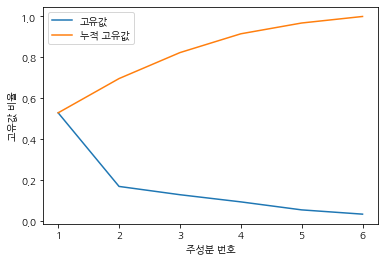

```python
# 고유값 비율 그래프 생성
plt.plot(df_pca_stat["PrinNo"], df_pca_stat["EigenValueRatio"], label="고유값")

# 누적된 고유값 비율 그래프 생성
plt.plot(df_pca_stat["PrinNo"], df_pca_stat["CumEigenValueRatio"], label="누적 고유값")
plt.ylabel("고유값 비율")
plt.xlabel("주성분 번호")
plt.legend(loc="best")
```

```python
# 주성분 분석 데이터의 변수 이름
x_cols = pd.DataFrame({"Feature": df_raw_x.columns})

# 주성분 Prin1~6까지의 고유벡터 저장
# 전치 결과 pd.DataFrame(pca.components_.T * -1, columns=["Prin1", "Prin2", "Prin3", "Prin4", "Prin5", "Prin6"])], axis=1)
# 파이썬 PCA 분석 시 SVD 연산 방식의 차이 반영(전치, 부호 변경)
df_eigenvector = pd.concat([x_cols, pd.DataFrame(pca.components_.T * -1, \
                            columns=["rin1", "Prin2", "Prin3", "Prin4", "Prin5", "Prin6"])], axis=1)
df_eigenvector.round(3)
```

|  | Feature | rin1 | Prin2 | Prin3 | Prin4 | Prin5 | Prin6 |
| --- | --- | --- | --- | --- | --- | --- | --- |
| 0 | DISSATIS | 0.439 | -0.313 | 0.445 | 0.316 | -0.192 | -0.612 |
| 1 | PRIVILEGE | 0.395 | -0.309 | 0.217 | -0.815 | -0.038 | 0.190 |
| 2 | CHANCE | 0.461 | -0.217 | -0.272 | 0.225 | 0.776 | 0.118 |
| 3 | ADVANCE | 0.493 | 0.116 | 0.006 | 0.365 | -0.460 | 0.631 |
| 4 | CRITISM | 0.225 | 0.802 | 0.457 | -0.100 | 0.289 | -0.058 |
| 5 | PROMOTION | 0.381 | 0.321 | -0.687 | -0.206 | -0.255 | -0.416 |

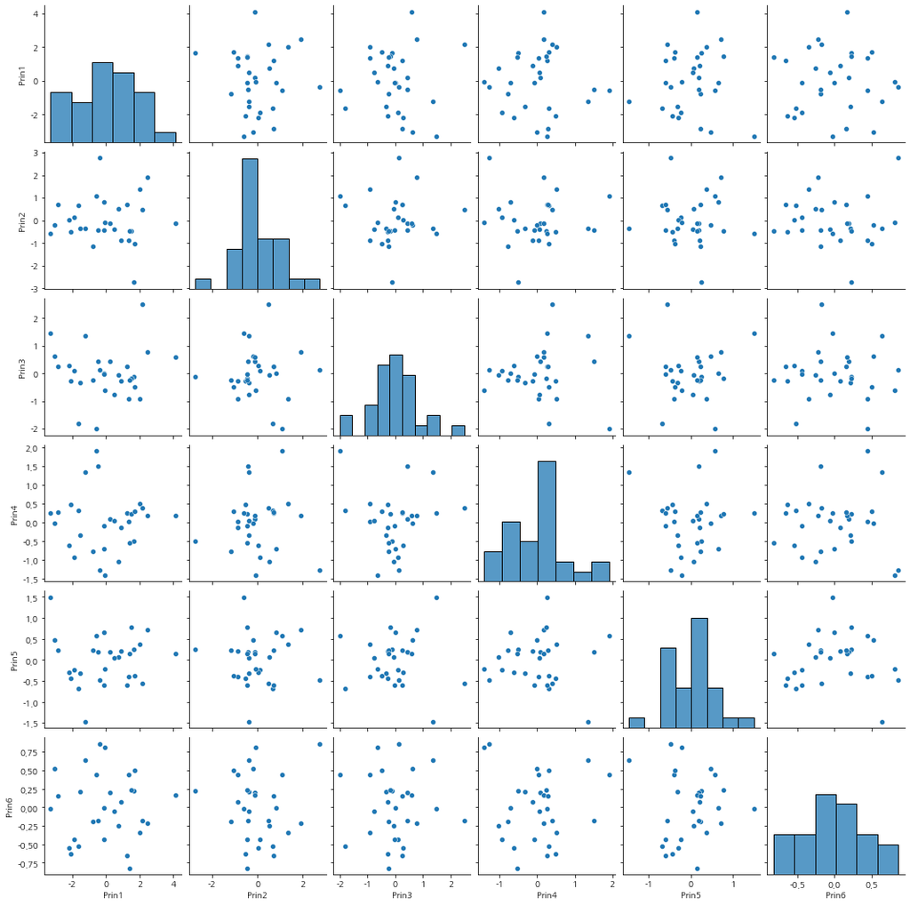

```python
# 산점도 행렬
sns.pairplot(df_pca)
```

```python
# 상관계수
df_pca.corr().round(3)
```

|  | Prin1 | Prin2 | Prin3 | Prin4 | Prin5 | Prin6 |
| --- | --- | --- | --- | --- | --- | --- |
| Prin1 | 1.0 | 0.0 | -0.0 | -0.0 | 0.0 | 0.0 |
| Prin2 | 0.0 | 1.0 | 0.0 | -0.0 | 0.0 | 0.0 |
| Prin3 | -0.0 | 0.0 | 1.0 | 0.0 | -0.0 | -0.0 |
| Prin4 | -0.0 | -0.0 | 0.0 | 1.0 | 0.0 | -0.0 |
| Prin5 | 0.0 | 0.0 | -0.0 | 0.0 | 1.0 | 0.0 |
| Prin6 | 0.0 | 0.0 | -0.0 | -0.0 | 0.0 | 1.0 |

주성분은 서로 독립적이기 때문에 상관계수가 0이다.

```python
# 다중선형 회귀분석: 원천 데이터 활용
# 원천 데이터에 절편(const) 추가
df_raw_x_const = sm.add_constant(df_raw_x)

#회귀모델 생성
reg_model = sm.OLS(df_raw_y, df_raw_x_const)

#회귀모델 적합
reg_model= reg_model.fit()

# 모델 성능 확인
print(reg_model.summary())

#*참조: Scale변환 데이터를 이용한 회귀분석
#다중선형 회귀분석: Scale 변환 데이터 활용
#Scale 변환 데이터에 절편(const) 컬럼추가
df_scaled_const = sm.add_constant(df_scaled)
reg_model = sm.OLS(df_raw_y, df_scaled_const)
reg_model = reg_model.fit()
print(reg_model.summary())
```

```
                            OLS Regression Results
==============================================================================
Dep. Variable:                   EVAL   R-squared:                       0.733
Model:                            OLS   Adj. R-squared:                  0.663
Method:                 Least Squares   F-statistic:                     10.50
Date:                Wed, 25 May 2022   Prob (F-statistic):           1.24e-05
Time:                        15:00:14   Log-Likelihood:                -97.250
No. Observations:                  30   AIC:                             208.5
Df Residuals:                      23   BIC:                             218.3
Df Model:                           6
Covariance Type:            nonrobust
==============================================================================
                 coef    std err          t      P>|t|      [0.025      0.975]
------------------------------------------------------------------------------
const         10.7871     11.589      0.931      0.362     -13.187      34.761
DISSATIS       0.6132      0.161      3.809      0.001       0.280       0.946
PRIVILEGE     -0.0731      0.136     -0.538      0.596      -0.354       0.208
CHANCE         0.3203      0.169      1.901      0.070      -0.028       0.669
ADVANCE        0.0817      0.221      0.369      0.715      -0.376       0.540
CRITISM        0.0384      0.147      0.261      0.796      -0.266       0.342
PROMOTION     -0.2171      0.178     -1.218      0.236      -0.586       0.152
==============================================================================
Omnibus:                        2.386   Durbin-Watson:                   1.795
Prob(Omnibus):                  0.303   Jarque-Bera (JB):                1.255
Skew:                          -0.081   Prob(JB):                        0.534
Kurtosis:                       2.011   Cond. No.                     1.34e+03
==============================================================================

Notes:
[1] Standard Errors assume that the covariance matrix of the errors is correctly specified.
[2] The condition number is large, 1.34e+03. This might indicate that there are
strong multicollinearity or other numerical problems.
                            OLS Regression Results
==============================================================================
Dep. Variable:                   EVAL   R-squared:                       0.733
Model:                            OLS   Adj. R-squared:                  0.663
Method:                 Least Squares   F-statistic:                     10.50
Date:                Wed, 25 May 2022   Prob (F-statistic):           1.24e-05
Time:                        15:00:14   Log-Likelihood:                -97.250
No. Observations:                  30   AIC:                             208.5
Df Residuals:                      23   BIC:                             218.3
Df Model:                           6
Covariance Type:            nonrobust
==============================================================================
                 coef    std err          t      P>|t|      [0.025      0.975]
------------------------------------------------------------------------------
const         64.6333      1.290     50.087      0.000      61.964      67.303
DISSATIS       8.0272      2.107      3.809      0.001       3.668      12.387
PRIVILEGE     -0.8788      1.633     -0.538      0.596      -4.256       2.499
CHANCE         3.6965      1.945      1.901      0.070      -0.326       7.719
ADVANCE        0.8355      2.264      0.369      0.715      -3.848       5.519
CRITISM        0.3734      1.430      0.261      0.796      -2.585       3.332
PROMOTION     -2.1957      1.803     -1.218      0.236      -5.925       1.534
==============================================================================
Omnibus:                        2.386   Durbin-Watson:                   1.795
Prob(Omnibus):                  0.303   Jarque-Bera (JB):                1.255
Skew:                          -0.081   Prob(JB):                        0.534
Kurtosis:                       2.011   Cond. No.                         4.07
==============================================================================

Notes:
[1] Standard Errors assume that the covariance matrix of the errors is correctly specified.
```

```python
#다중 선형 주성분 회귀분석: 주성분 점수(score) 데이터 활용
#Eigenvalue, Scree plot 기준으로 적정 주성분 선택
x_var= ["Prin1", "Prin2", "Prin3"]

#선택된 주성분 점수 데이터에 절편(const)컬럼 추가
df_pca_const = sm.add_constant(df_pca[x_var])

#회귀 모델 생성
reg_model = sm.OLS(df_raw_y, df_pca_const)

#회귀 모델 적합
reg_model = reg_model.fit()

#모델 성능 확인
print(reg_model.summary())
```

```
                            OLS Regression Results
==============================================================================
Dep. Variable:                   EVAL   R-squared:                       0.624
Model:                            OLS   Adj. R-squared:                  0.580
Method:                 Least Squares   F-statistic:                     14.36
Date:                Wed, 25 May 2022   Prob (F-statistic):           1.02e-05
Time:                        15:00:33   Log-Likelihood:                -102.38
No. Observations:                  30   AIC:                             212.8
Df Residuals:                      26   BIC:                             218.4
Df Model:                           3
Covariance Type:            nonrobust
==============================================================================
                 coef    std err          t      P>|t|      [0.025      0.975]
------------------------------------------------------------------------------
const         64.6333      1.440     44.890      0.000      61.674      67.593
Prin1         -4.5451      0.809     -5.620      0.000      -6.208      -2.883
Prin2          3.3489      1.435      2.333      0.028       0.399       6.299
Prin3         -4.0601      1.648     -2.463      0.021      -7.448      -0.672
==============================================================================
Omnibus:                        1.252   Durbin-Watson:                   2.154
Prob(Omnibus):                  0.535   Jarque-Bera (JB):                1.044
Skew:                          -0.237   Prob(JB):                        0.593
Kurtosis:                       2.219   Cond. No.                         2.04
==============================================================================

Notes:
[1] Standard Errors assume that the covariance matrix of the errors is correctly specified.
```

## 시계열 분석

```python
import pandas as pd
import numpy as np
import matplotlib
import matplotlib.pyplot as plt
from datetime import datetime

import statsmodels.api as sm
from statsmodels.graphics.tsaplots import plot_acf, plot_pacf
from statsmodels.tsa.arima_model import ARIMA
```